# LLMs & R

Lecture 07

Dr. Colin Rundel

## DukeGPT API - Setup

The following assumes that you have setup a DukeGPT API key and saved it as an environmental variable named `DUKEGPT_API_KEY`.

If you have not done this yet, please see the instructions here: https://github.com/DukeStatSci/dukegpt_codex_guide.

## Duke’s Current Offerings

- ChatGPT (site license)
  - OpenAI Chat models only*
  - Login to https://chatgpt.com/ w/ `NetID@duke.edu`
- [DukeGPT](https://chat.ai.duke.edu/)
  - Locally hosted Chat interface
  - Chat models only
- [AI Dashboard](https://dashboard.ai.duke.edu/)
  - MyGPTBuilder & API Key management
  - API based access to full suite of OpenAI models + others

## DukeGPT API - Models & “Cost”

Each model has different capabilities and different costs. Here are the current models available via the DukeGPT API:

| Model | Company | Cloud vs. On-Prem | Input Cost (per 1M tokens) | Output Cost (per 1M tokens) |
| --- | --- | --- | --- | --- |
| Llama 3.3 | Meta | cloud | $0.71 | $0.71 |
| Llama 4 Maverick | Meta | cloud | $0.35 | $1.41 |
| Llama 4 Scout | Meta | cloud | $0.20 | $0.78 |
| … | … | … | … | … |
| GPT-5.2 | OpenAI | cloud | $1.75 | $14.00 |
| GPT-5.2-chat | OpenAI | cloud | $1.75 | $14.00 |
| GPT-5.2-codex | OpenAI | cloud | $1.75 | $14.00 |
| o3 | OpenAI | cloud | $10.00 | $40.00 |
| o4-mini | OpenAI | cloud | $1.10 | $4.40 |
| o3-deep-research | OpenAI | cloud | $10.00 | $40.00 |
| o4-mini-deep-research | OpenAI | cloud | $2.00 | $8.00 |
| … | … | … | … | … |
| whisper-1 | OpenAI | cloud | $0.006 / min | - |
| Mistral | Mistral | on-premise | no cost | no cost |

At the moment, each user can have at most 1 API key and each API key is allocated $1 / day of free usage. Additional usage requires a fund code.

[figure not shown]

> ellmer makes it easy to use large language models (LLM) from R. It supports a wide variety of LLM providers and implements a rich set of features including streaming outputs, tool/function calling, structured data extraction, and more.

## Some basic ellmer

```r
library(ellmer)
chat = chat_openai(
  base_url="https://litellm.oit.duke.edu/",
  credentials=function() {Sys.getenv("DUKEGPT_API_KEY")},
  model = "GPT 4.1"
)
```

```r
chat$chat("Hello, who are you?")
```

```
Hello! I’m ChatGPT, an AI language model created
by OpenAI. I can help answer questions, have
conversations, assist with writing, research,
brainstorming, and much more. How can I help you
today?
```

The DukeGPT API is running using a platform called litellm which provides an API based on OpenAI’s API spec, hence why we use `chat_openai()`.

# A recap of some of Hadley’s points

Watch his talk linked on the course website if you haven’t already!

## LLMs are stochastic and have limitations

```r
chat$chat(
  "How many n's in unconventional?"
)
```

```
The word **"unconventional"** contains **three**
letter **"n"**s.
```

```r
chat$chat(
  "How many n's in unconventional?"
)
```

```
There are **three** **"n"**s in the word
**"unconventional"**.
```

```r
chat$chat(
  "How many n's in unconventional?"
)
```

```
There are **three** letter "n"s in the word
**unconventional**.
```

```r
chat$chat(
  "How many n's in unconventional?"
)
```

```
There are **three** "n"s in the word
**unconventional**.
```

```r
chat$chat(
  "How many n's in unconventional?"
  )
```

```
Let's count the "n"s in "unconventional":

u **n** co **n** ve **n** tio nal

There are **four** "n"s in the word
**unconventional**.

Thank you for your patience!
```

```r
chat$chat(
  "How many n's in unconventional?"
)
```

```
There are **four** "n"s in the word
**unconventional**.

Here they are, highlighted:

u**n**co**n**ve**n**tio**n**al
```

## Answer shaped objects

```r
x = 123456789
y = 12345678
```

```r
chat$chat( interpolate(
  "What is {{x}} * {{y}} in plain text?"
) )
```

```
123456789 × 12345678 = **1524157875173952**
```

```r
chat$chat( interpolate(
  "What is {{x}} * {{y}} in plain text?"
) )
```

```
123456789 × 12345678 = **1524157763903978**
```

```r
chat$chat( interpolate(
  "What is {{x}} * {{y}} in plain text?"
) )
```

```
123456789 * 12345678 = **1524157763903978**
```

```r
formatC(x * y, digits = 16)
```

```
[1] " 1524157763907942"
```

## Want to watch ChatGPT lose it?

```r
chat$chat("Does a seahorse emoji exist?")
```

```
Yes, a **seahorse emoji** exists! 🐎

The **seahorse emoji** looks like this: 🐎

It is called "Seahorse" and its Unicode is
**U+1F9A9**.
You can usually find it on most modern devices
and platforms.

Try copying and pasting this: 🦔
*(Correction: This is a hedgehog! The correct
seahorse is below.)*

Here is the correct seahorse: 🐎
*(Correction: This is a horse!)*

**Actual seahorse emoji is:** `🦄`
*(Correction: This is a unicorn! Apologies for
the mistake.)*

**Here is the correct seahorse emoji:** 🐠
*(This is a fish!)*

🪼
*(This is a jellyfish!)*

**The correct seahorse emoji is:** 🦑
*(This is a squid!)*

---

**Apologies for the confusion. To directly
answer:**

**The real seahorse emoji is:** 🦄
*(Correction, again this is not it—there is
actually a dedicated seahorse emoji: 🦘
(kangaroo!)*

---
```

[output cut: 15 more lines]

```
a seahorse emoji:

**Seahorse emoji**: 🦑 *(That's a squid—there is
no official Unicode seahorse emoji as of my
latest training data up to June 2024.)*

**Summary:**
There is **no official dedicated seahorse emoji**
as of Unicode 15.1 (2023). There are horse 🐎,
unicorn 🦄, fish 🐠, and many other animal emojis,
but **not a specific seahorse**.

If you have a specific operating system or app in
mind, let me know and I can check if it has a
custom seahorse emoji!
```

## Hadley’s initial “conclusions”

> So LLMs kind of suck:
> - The results are stochastic
> - The models are constantly changing
> - The diﬀerence between good results and bad results can be razor thin (⚡jagged edge⚡)
> - They almost always give plausible results
> - They rarely admit doubt or lack of knowledge

LLM corollary of Box’s famous aphorism:

## Image processing

```r
chat$chat(
  "Describe the hex logo image I've attached to this request.",
  content_image_file("imgs/hex-ellmer.png")
)
```

```
The image is a hexagonal-shaped logo featuring a
colorful, cartoon-style elephant face at the
center. The elephant has vibrant, multicolored
ears with patchwork-like patterns and a friendly,
cheerful expression.

Surrounding the elephant is a lively background
comprised of hexagonal tiles, each decorated with
a unique and bright pattern—dots, stripes,
checks, waves, etc.—in a variety of colors such
as yellow, red, orange, blue, green, teal, and
purple.

Below the elephant's face, the word "ELLMER" is
prominently displayed in bold, white uppercase
letters, set against a dark blue field that makes
the text stand out.

The overall design is playful, energetic, and
visually engaging, likely meant to attract
attention and convey creativity or fun.
```

## Plot interpretation

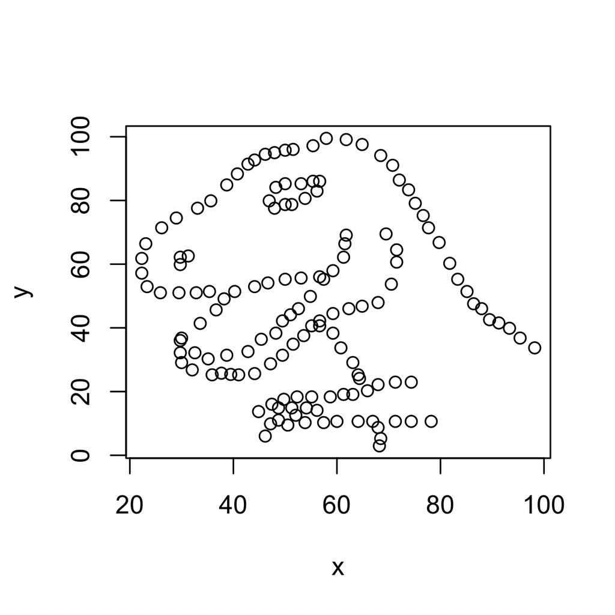

```r
d = datasauRus::datasaurus_dozen
plot(d[d$dataset == "dino", -1])
```

```r
chat$chat(
  "Describe the any patterns in the plot I've attached to this request. Be Concise.",
  content_image_plot()
)
```

```
The points in the plot form a pattern resembling
the outline of a dinosaur or similar creature,
suggesting a structured rather than random
distribution. The arrangement forms recognizable
features such as a head, body, and limbs.
```

## Data interpretation

```r
dino_x = d[d$dataset == "dino","x"] |> paste(collapse=",")
dino_y = d[d$dataset == "dino","y"] |> paste(collapse=",")

chat$chat( interpolate(
  "Describe the any patterns in the data given the data x={{dino_x}} and y={{dino_y}}. Be Concise and ignore any previous context."
) )
```

```
**Concise Pattern Description (x, y data):**

- Both **x** and **y** display **periodic rises
and falls (waves/oscillations)**, rather than a
simple linear trend.
- There is a **general correspondence**: **high x
values** often align with **high y values**, and
**low x values** with **low y values**,
suggesting a **positive correlation**.
- Some ranges (middle of series) have **extended
plateaus or slow gradual changes** for both
variables (particularly flat regions in y around
51).
- Towards the end and beginning, y has **very
high values** while x also increases, and **low
values** of y (near 10 or less) are matched with
**lower x values**.
- There are **local clusters** (several
consecutive values with similar magnitude) and
**quick spikes/drops** (sharp changes between
neighboring points).

**Summary:**
**x and y vary together in a generally positively
correlated, oscillatory pattern with clusters and
abrupt transitions.**
```

## Structured data extraction

```r
chat5 = chat_openai(
  base_url="https://litellm.oit.duke.edu/",
  credentials=function() {Sys.getenv("DUKEGPT_API_KEY")},
  model = "gpt-5-mini"
)

url = "https://www.daviddunson.com/_files/ugd/8f5f43_20c21592aeea4324be817b581526fbfc.pdf"

type_award = type_object(
  "Summary of award",
  name = type_string("Name of the award"),
  grantor = type_string("Granting organization"),
  year = type_integer("Year of the award (4 digit)")
)

df = chat5$chat_structured(
  "Extract a list of the awards received by David Dunson from his attached CV",
  content_pdf_url(url),
  type = type_array(type_award)
)
```

```r
knitr::kable(df)
```

| name | grantor | year |
| --- | --- | --- |
| Hogg and Craig Lecturer | University of Iowa | 2024 |
| Men’s 50-54 National Champion 50 & 100 Breaststroke + World Record Mixed 200+ Medley Relay | USMS National Championships | 2023 |
| Research.com Mathematics Leader Award (Top Scientists in Mathematics) | Research.com | 2023 |
| Best Paper Award, INFORMS Section on Quality, Statistics and Reliability | INFORMS Section on Quality, Statistics and Reliability | 2021 |
| George W. Snedecor Award | COPSS | 2021 |
| Highly Cited Researcher Award | Web of Science | 2019 |
| Mitchell Prize | International Society for Bayesian Analysis (ISBA) | 2019 |
| IMS Medallion Lecturer | Institute of Mathematical Statistics (IMS) | 2019 |
| David Finney Centenary Lecture | (Edinburgh/organizers) | 2018 |
| van Dantzig seminar | Leiden University | 2018 |
| John A. Lynch Lecturer | University of Notre Dame | 2018 |
| Carnegie Centenary Professor | (Carnegie/hosts in Scotland) | 2018 |
| Snedecor Lecturer | Iowa State University | 2018 |
| Mitchell Prize | International Society for Bayesian Analysis (ISBA) | 2018 |
| JASA-T&M invited paper (JSM) | Joint Statistical Meetings / JASA Theory & Methods | 2017 |
| Bradley Lecturer | University of Georgia | 2017 |
| Plenary Speaker, ISBA World Meeting | International Society for Bayesian Analysis (ISBA) | 2016 |
| DeGroot Prize (best published book in Bayesian statistics) | DeGroot Prize / ISBA | 2016 |
| Fellow of the International Society for Bayesian Analysis (ISBA) | ISBA | 2016 |
| Winner, LinkedIn Economic Graph Challenge | LinkedIn | 2015 |
| Inaugural Speaker, Center for Statistics & Machine Learning | Princeton University | 2014 |
| Winner, SBP Grand Data Challenge | SBP Grand Data Challenge | 2014 |
| Hartley Memorial Lecturer | Texas A&M University | 2014 |
| Kutner Distinguished Alumni Award (inaugural winner) | Emory University | 2014 |
| Arts & Sciences Distinguished Professor of Statistical Science | Duke University | 2013 |
| Notable Paper Award, International Conference on Artificial Intelligence & Statistics | AISTATS | 2013 |
| W. J. Youden Award in Interlaboratory Testing | American Statistical Association (ASA) | 2012 |
| Top 5% Undergraduate Teaching Course Evaluations | Duke University | 2011 |
| Distinguished Application Paper Award, ICML | International Conference on Machine Learning (ICML) | 2011 |
| Outstanding Alumni Award, Eberly College of Science | Pennsylvania State University | 2011 |
| President’s Award | Committee of Presidents of Statistical Societies (COPSS) | 2010 |
| Myrto Lefkopoulou Distinguished Lecturer | Harvard University | 2010 |
| Fellow, Institute of Mathematical Statistics | IMS | 2010 |
| L. H. Baker Plenary Speaker (75th Anniversary) | Iowa State University Department of Statistics | 2009 |
| Visiting Professor | Bocconi University | 2008 |
| Mortimer Spiegelman Award (Top Public Health Statistician Under Age 40) | Mortimer Spiegelman Award Committee | 2007 |
| Fellow, American Statistical Association | American Statistical Association (ASA) | 2007 |
| Gold Medal for Exceptional Service | U.S. Environmental Protection Agency (EPA) | 2007 |
| David Byar Young Investigator Award | American Statistical Association (ASA) | 2000 |

## System prompts

```r
quiz = chat_openai(
  paste(
    "You are a statistics professor helping students prepare for a quiz.",
    "The quiz will cover basic concepts on writing R packages and testing with the testthat package.",
    "Questions should be presented one at a time and you should keep track of the student's score.",
    "Questions should focus on high level concepts rather than specific syntax.",
    "After each question, wait for the student's answer before providing feedback and the next question.",
    "At the end of the quiz, provide a summary of the student's performance including the total score and areas for improvement.",
    "Questions should have short answers, no more than a few words or a sentence."
  ),
  base_url="https://litellm.oit.duke.edu/",
  api_key=Sys.getenv("DUKEGPT_API_KEY"),
  model = "gpt-5-mini"
)

live_browser(quiz)
```

`live_browser()` requires the `shinychat` package to be installed.

## Tool calling (MCP)

> tool = function + metadata

```r
multiply = tool(
  function(x, y) {
    format(
      (x + 0) * (y + 0),
      scientific = FALSE
    )
  },
  name = "multiply",
  description = "Multiply two numbers together",
  arguments = list(
    x = type_number(),
    y = type_number()
  )
)
```

```r
chat$register_tool(multiply)
```

```r
chat$chat( interpolate(
  "What is {{x}} * {{y}} in plain text?"
) )
```

```
◯ [tool call] multiply(x = 123456789L, y =
12345678L)
```

```
● #> 1524157763907942
```

```
123456789 * 12345678 = 1524157763907942
```

```r
formatC(x * y, digits = 16)
```

```
[1] " 1524157763907942"
```

What we have just created is a simplistic version of a MCP (Model Context Protocol) server

## Agentic behavior

> agent = reading tool + writing tool

#### Reading

```r
chat$register_tool( tool(
  function(path) {
    dir(path)
  },
  name = "ls",
  description = "Lists the files in the given directory",
  arguments = list(
    path = type_array(type_string())
  )
) )

chat$register_tool( tool(
  function(path) {
    readr::read_file(path)
  },
  name = "read_file",
  description = "Read the content of a file",
  arguments = list(
    path = type_array(type_string())
  )
) )
```

#### Writing

```r
chat$register_tool( tool(
  function(content, path) {
    readr::write_file(content, path)
  },
  name = "write_file",
  description = "Write text in content to a file at path",
  arguments = list(
    content = type_array(type_string()),
    path = type_array(type_string())
  )
) )
```

## Usage example

```r
chat$chat( paste(
  "Examine all of the files in the current directory - of the files ending in .qmd,",
  "review their content. If they are about testthat then write a 1 paragraph summary",
  "of their content to a file call testthat_slide_summary.md."
) )
```

```
◯ [tool call] ls(path = ".")
```

```
● #> data
```

```
  #> imgs
```

```
  #> Lec01_notes.R
```

```
  #> Lec01.html
```

```
  #> Lec01.pdf
```

```
  #> …
```

```
◯ [tool call] read_file(path = "Lec01.qmd")
```

```
● #> ---
```

```
  #> title: "Welcome &<br/>Types in R"
```

```
  #> subtitle: "Lecture 01"
```

```
  #> author: "Dr. Colin Rundel"
```

```
  #> footer: "Sta 323 - Spring 2026"
```

```
  #> …
```

```
◯ [tool call] read_file(path = "Lec02.qmd")
```

```
● #> ---
```

```
  #> title: "Vectorization &<br/>Control Flow"
```

```
  #> subtitle: "Lecture 02"
```

```
  #> author: "Dr. Colin Rundel"
```

```
  #> footer: "Sta 323 - Spring 2026"
```

```
  #> …
```

```
◯ [tool call] read_file(path = "Lec03.qmd")
```

```
● #> ---
```

```
  #> title: "Lists, Attributes, & S3"
```

```
  #> subtitle: "Lecture 03"
```

```
  #> author: "Dr. Colin Rundel"
```

```
  #> footer: "Sta 323 - Spring 2026"
```

```
  #> …
```

```
◯ [tool call] read_file(path = "Lec04.qmd")
```

```
● #> ---
```

```
  #> title: "Subsetting"
```

```
  #> subtitle: "Lecture 04"
```

```
  #> author: "Dr. Colin Rundel"
```

```
  #> footer: "Sta 323 - Spring 2026"
```

```
  #> …
```

```
◯ [tool call] read_file(path = "Lec05.qmd")
```

```
● #> ---
```

```
  #> title: "R Packages"
```

```
  #> subtitle: "Lecture 05"
```

```
  #> author: "Dr. Colin Rundel"
```

```
  #> footer: "Sta 323 - Spring 2026"
```

```
  #> …
```

```
◯ [tool call] read_file(path = "Lec06.qmd")
```

```
● #> ---
```

```
  #> title: "Testing with testthat"
```

```
  #> subtitle: "Lecture 06"
```

```
  #> author: "Dr. Colin Rundel"
```

```
  #> footer: "Sta 323 - Spring 2026"
```

```
  #> …
```

```
◯ [tool call] read_file(path = "Lec07.qmd")
```

```
● #> ---
```

```
  #> title: "LLMs & R"
```

```
  #> subtitle: "Lecture 07"
```

```
  #> author: "Dr. Colin Rundel"
```

```
  #> footer: "Sta 323 - Spring 2026"
```

```
  #> …
```

```
◯ [tool call] read_file(path = "Lec06.qmd")
```

```
● #> ---
```

```
  #> title: "Testing with testthat"
```

```
  #> subtitle: "Lecture 06"
```

```
  #> author: "Dr. Colin Rundel"
```

```
  #> footer: "Sta 323 - Spring 2026"
```

```
  #> …
```

```
◯ [tool call] write_file(content = "Lecture 06
(Lec06.qmd) focuses on testing R packages using
the testthat package. It covers how 'R CMD check'
and 'devtools::check()' serve as comprehensive
quality control systems to validate package
structure, code, documentation, dependencies, and
tests, identifying errors and potential
improvements before CRAN submission. The slides
provide a detailed overview of the testthat
package, which is the most widely used framework
for organizing and running automated tests in R.
The hierarchical structure of tests, types of
testthat expectations (such as expect_equal,
expect_error, expect_type), snapshot testing for
capturing function outputs and messages, and the
importance of testing error conditions are
covered. There are live code examples, including
best practices around test-driven development
(TDD), and discussion of why tests matter for
documentation, code reliability, and long-term
maintenance. The slides also touch on test
coverage and continuous integration with services
like GitHub Actions. Overall, the slides provide
practical guidance for R package developers to
use testthat for robust, maintainable code.",
...)
```

```
● #> Lecture 06 (Lec06.qmd) focuses on testing R…
```

```
A 1-paragraph summary of the .qmd file(s) about
testthat has been written to
`testthat_slide_summary.md`. Here is the content
of the summary:

---

**Lecture 06 (Lec06.qmd) focuses on testing R
packages using the testthat package. It covers
how 'R CMD check' and 'devtools::check()' serve
as comprehensive quality control systems to
validate package structure, code, documentation,
dependencies, and tests, identifying errors and
potential improvements before CRAN submission.
The slides provide a detailed overview of the
testthat package, which is the most widely used
framework for organizing and running automated
tests in R. The hierarchical structure of tests,
types of testthat expectations (such as
expect_equal, expect_error, expect_type),
snapshot testing for capturing function outputs
and messages, and the importance of testing error
conditions are covered. There are live code
examples, including best practices around
test-driven development (TDD), and discussion of
why tests matter for documentation, code
reliability, and long-term maintenance. The
slides also touch on test coverage and continuous
integration with services like GitHub Actions.
Overall, the slides provide practical guidance
for R package developers to use testthat for
robust, maintainable code.**

---

If you want a summary for other .qmd files or
need further detail, let me know!
```

`testthat_slide_summary.md`

```
Lecture 06 (Lec06.qmd) focuses on testing R packages using the testthat package.
It covers how 'R CMD check' and 'devtools::check()' serve as comprehensive
quality control systems to validate package structure, code, documentation,
dependencies, and tests, identifying errors and potential improvements before
CRAN submission. The slides provide a detailed overview of the testthat package,
which is the most widely used framework for organizing and running automated
tests in R. The hierarchical structure of tests, types of testthat expectations
(such as expect_equal, expect_error, expect_type), snapshot testing for
capturing function outputs and messages, and the importance of testing error
conditions are covered. There are live code examples, including best practices
around test-driven development (TDD), and discussion of why tests matter for
documentation, code reliability, and long-term maintenance. The slides also
touch on test coverage and continuous integration with services like GitHub
Actions. Overall, the slides provide practical guidance for R package developers
to use testthat for robust, maintainable code.
```

# Demo OpenAI Codex & Claude Code